# Final Homework

Anna Vietmeier

7/23/2021

## Precipitation Patterns

*Albasini Dam, South Africa*

### Introduction

**Due 27 July 2021**

The average precipitation for the hydrological year from 1980-2020 is represented in a bar plot (**Figure 1**). The average monthly precipitation from 1980-2020 and the standard deviation for each month is represented in a bar plot with error bars (**Figure 2**). Annual precipitation data from 1980-2000 and 2001-2020 were grouped together to compare for significant difference in perciptation using a t-test (**Figure 3**).

### Annual Precipitation

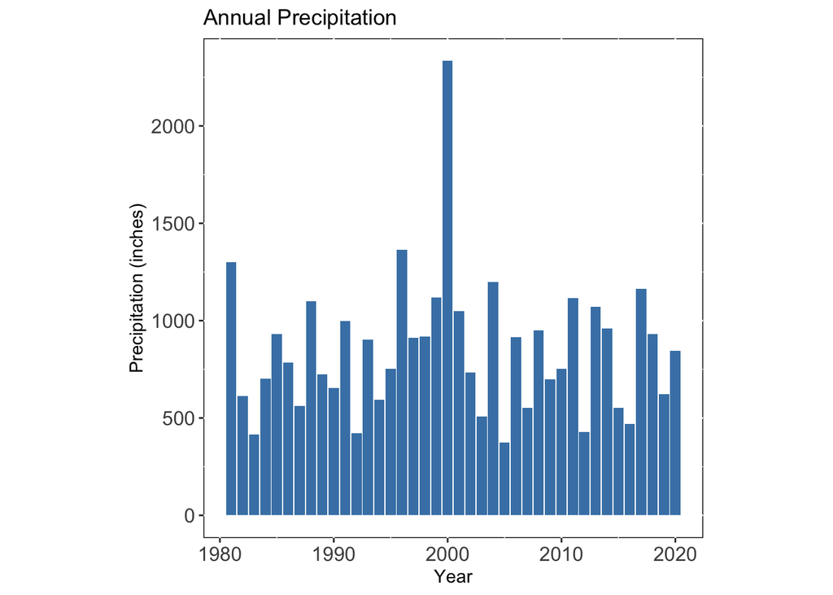

**Figure 1.** Albansi Dam, South Africa annual precipitation reported in inches from 1980-2020. The highest amount of precipitation was reported in 2000, and the lowest amount of precipitation was reported in 2005.